# Sales

Fiona Wang

2025-02-12

```r
library(tidyverse)
library(dplyr)
library(readxl)
```

- Read in the Excel file called `sales.xlsx` from the `data-raw/` folder such that it looks like the following.

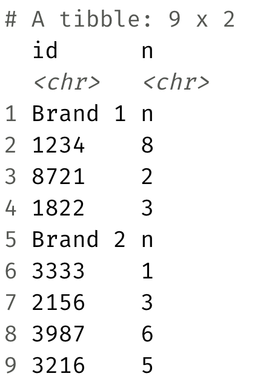

```r
sales <- read_excel("data-raw/sales.xlsx")
sales <-sales %>%
  filter(!is.na(...2))
sales <- sales %>%
  rename(id = `This file contains information on sales.`)
sales <- sales %>%
  rename(n = ...2)
tibble(sales)
```

```
## # A tibble: 9 × 2
##   id      n
##   <chr>   <chr>
## 1 Brand 1 n
## 2 1234    8
## 3 8721    2
## 4 1822    3
## 5 Brand 2 n
## 6 3333    1
## 7 2156    3
## 8 3987    6
## 9 3216    5
```

- **Stretch goal:** Manipulate the sales data such such that it looks like the following.

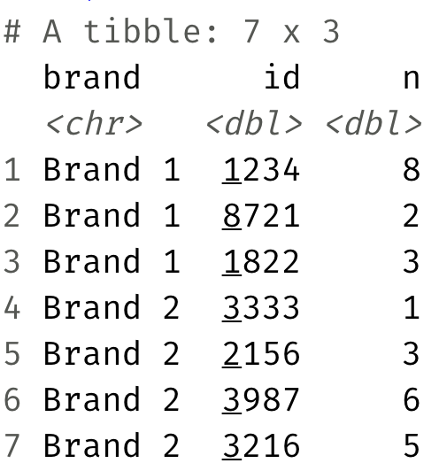

```r
sales2 <- read_excel("data-raw/sales.xlsx")
sales2 <-sales2 %>%
  filter(!is.na(...2))
Brand <- c("Brand 1", "Brand 1", "Brand 1", "Brand 2", "Brand 2", "Brand 2", "Brand 2")
id <- c("1234", "8721", "1822", "3333", "2156", "3987", "3216")
n <- c("8", "2", "3", "1", "3", "6", "5")
sales2 <- tibble(Brand, id, n)
sales2 <- sales2 %>%
  mutate(
    id = as.numeric(id),
    n = as.numeric(n)
  )
sales2
```

```
## # A tibble: 7 × 3
##   Brand      id     n
##   <chr>   <dbl> <dbl>
## 1 Brand 1  1234     8
## 2 Brand 1  8721     2
## 3 Brand 1  1822     3
## 4 Brand 2  3333     1
## 5 Brand 2  2156     3
## 6 Brand 2  3987     6
## 7 Brand 2  3216     5
```

## Hint

?read_excel read_excel(path, sheet = NULL, range = NULL, col_names = TRUE, col_types = NULL, na = ““, trim_ws = TRUE, skip = 0, n_max = Inf, guess_max = min(1000, n_max), progress = readxl_progress(), .name_repair =”unique”)

1. when you import the data, you can skip redundant rows. in this case, skip=3 seems great.
2. when you import the data, you can assign column names. col_names=c(“id”,“n”)
3. you can make new variable that can detect if vector contains certain value, using mutate() and str_detect(). in this case, we need to detect if “Brand” is in “id”column or not.
4. if_else() function would be useful.
5. fill() function is needed.

so, your answer would be like this : ??<-read_excel(“data-raw/sales.xlsx”, ???,???)

?<-?%>% mutate( ?? = str_detect(id,“Brand”), brand = if_else(??,id,NULL) ) %>% fill(brand) %>% filter(??) %>% select(brand,id,n)

## References

1. Assignment Adapted from [Mine Cetinkaya-Rundel’s Data Science in a Box](https://github.com/rstudio-education/datascience-box)